# Integration of scRNA & scATAC using bindSC

Jinzhuang Dou @ Kenchen’s lab (MDACC)

February 9, 2021

This guide will demonstrate the usage of bindSC to jointly define cell types by leveraging mulitple single-cell modalities. Here we define cell types that incorporate both gene expression and chromatin accessibility data. The dataset is generated from the sci-CAR technology (Cao et al., 2018, science).

#### Stage 1: Load the sciRNA-seq and sciATAC-seq data

**For convenience, we have prepared the pre-processed data which are ready to use.** User can refer to `A549_preprocess.ATAC.html` and `A549_preprocess.RNA.html` for the details of running the pre-processing workflow (It will take 10 ~ 20 mins). For RNA data, there are 6,005 cells measured on 4,759 genes (`A549_RNA$X`). For ATAC data, there are 3,628 cells measured on 13,515 genes (gene activity estimated from peak; `A549_ATAC$Z0`) and 24,953 peaks (`A549_ATAC$Y`). User can download the preprocessed sci-RNA data from https://drive.google.com/file/d/1tjMA9yERXYBx-GKKrGORKF1-4Zs9xScM/view?usp=sharing

The preprocessed sci-ATAC data from https://drive.google.com/file/d/1REKXV-TTm1rkWEyX82Q1R6dOtE-dPsza/view?usp=sharing

```r
library(bindSC)

A549_RNA <- readRDS("../../data/A549_rna.rds")
A549_ATAC <- readRDS("../../data/A549_atac.rds")

summary(A549_RNA)
summary(A549_ATAC)
dim(A549_RNA$X)
dim(A549_ATAC$Z0)
dim(A549_ATAC$Y)
```

We then visualize each cell, colored by cell type, from two technologies. Left is from scRNA-seq and right is from scATAC-seq. For both technologies, cells from 0 h and 1/3 h can be well separated in 2D-UMAP.

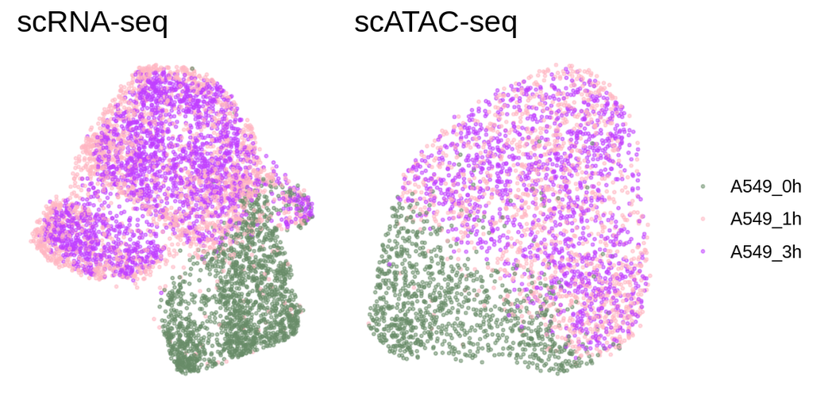

```r
library(ggpubr)
p1<-ggscatter(A549_RNA$RNA_meta, x = "UMAP_1", y = "UMAP_2",
   color = "cell_type", palette = c("darkseagreen4","lightpink","darkorchid1"),
   repel = FALSE,size=0.5, alpha=0.5,legend.title = "", title="scRNA-seq", font.title=16)

p2<-ggscatter(A549_ATAC$ATAC_meta, x = "UMAP_1", y = "UMAP_2",
   color = "group", palette = c("darkseagreen4","lightpink","darkorchid1"),
   repel = FALSE,size=0.5, alpha=0.5,legend.title = "", title="scATAC-seq", font.title=16)

p1<-p1+rremove("axis") + rremove("ticks") + rremove("xylab")+ rremove("axis.text")
p2<-p2+rremove("axis") + rremove("ticks") + rremove("xylab")+ rremove("axis.text")

p<-ggarrange(p1, p2, nrow = 1, common.legend = TRUE, legend = "right")
p
```

#### Stage 2: Preparation of bindSC input

We next perform bindSC alignment on A549 data. In generall, bindSC requires three matrices as input:

- `X` : gene expression matrix from scRNA-seq data
- `Y` : chromatin accessibility matrix from scATAC-seq data
- `Z0` : initilized gene activity matrix from scATAC-seq data

The gene activity matrix `Z0` is estimated by counting the total number of ATAC-seq reads within the gene body/promoter region of each gene in each cell.

```r
X <- A549_RNA$X
Y <- A549_ATAC$Y
Z0 <- A549_ATAC$Z0


treatmentTime <- c(A549_RNA$RNA_meta$treatment_time, A549_ATAC$ATAC_meta$group)
treatmentTime[treatmentTime=="A549_0h"] <- 0
treatmentTime[treatmentTime=="A549_1h"] <- 1
treatmentTime[treatmentTime=="A549_3h"] <- 3

type <- c(rep("scRNA-seq",nrow(A549_RNA$RNA_meta)), rep("scATAC-seq",nrow(A549_ATAC$ATAC_meta)))
```

Make sure `X` and `Z0` have matched gene features, `Y` and `Z0` have matched cell names.

```r
gene.overlap <- intersect(rownames(X), rownames(Z0))
cell.overlap <- intersect(colnames(Y), colnames(Z0))

X <- as.matrix(X[gene.overlap,])
Z0 <- as.matrix(Z0[gene.overlap, cell.overlap])
Y <- as.matrix(Y[,cell.overlap])
```

Generally, you can run bindSC using above inputs. However, the feature dimension is high for single cell epigenetic profiles (for example, >100k peaks for scATAC-seq data). Here we use low-dimension representations rather than the orignal matrixs for bindSC alignment. You should perform dimension reductions (SVD) on `X` and `Z0` jointly.

```r
out <- dimReduce( dt1 =  X, dt2 = Z0,  K = 30)
x <- out$dt1
z0 <- out$dt2
y  <- dimReduce(dt1 = Y, K=30)
```

#### Stage 3: Parameter optimization [optional]

To run the `parameter optimization` step, you need to prepare for the cluster annotaion information for each dataset.

```r
X.clst <- treatmentTime[type=="scRNA-seq"]
Y.clst <- treatmentTime[type=="scATAC-seq"]

# Given cells from 1/3hs are not separatable in A549 dataset, we only consider pre/post treatments
x.clst <- X.clst
y.clst <- Y.clst
x.clst[x.clst>0] <- 1
y.clst[y.clst>0] <- 1
run <- FALSE
if(run){
  paraSel <- BiCCA_para_opt( X = t(x) ,
               Y = t(y),
               Z0 =t(z0),
               X.clst = x.clst,
               Y.clst = y.clst,
               alpha.lst= seq(0,1,0.1),
               K.lst = c(5),
               lambda.lst = seq(0,1,0.1),
               num.iteration = 50,
               tolerance = 0.01,
               save = TRUE,
               block.size = 1000
  )
}
```

```r
run <- FALSE
if(run){
  p1 <- paraSel_plot(paraSel)
  p1

  tiff("paraSel.tiff", width=12, height =3, res =300, units = "in")
  print(p1)
  dev.off()
}
```

#### Stage 4: Run bindSC

We use defualt settings with lambda = 0.5 and alpha = 0.1. The iteration process will be done in ~10s.

```r
res <- BiCCA( X = t(x) ,
             Y = t(y),
             Z0 =t(z0),
             X.clst = x.clst,
             Y.clst = y.clst,
             alpha = 0.1,
             lambda = 0.5,
             K = 5,
             temp.path  = "out",
             num.iteration = 50,
             tolerance = 0.01,
             save = TRUE,
             parameter.optimize = FALSE,
             block.size = 0)
```

```
## 2021-06-08 17:12:05  Started!
```

```
## 2021-06-08 17:12:05  Dimension Check: X[30x6005] Y[30x3628] Z0[30x3628]
```

```
## 2021-06-08 17:12:05  Decomposing started!
```

```
## 2021-06-08 17:12:11  Done! The decomposition is converged.
```

Check the iteration process using `plotIteration` function (optional). The first row shows the objective function costs for 3 terms separately. The fourth figure shows the total objective function over iteration time. The fifth figure figure shows the relative change of gene score matrix Z over iteration time.

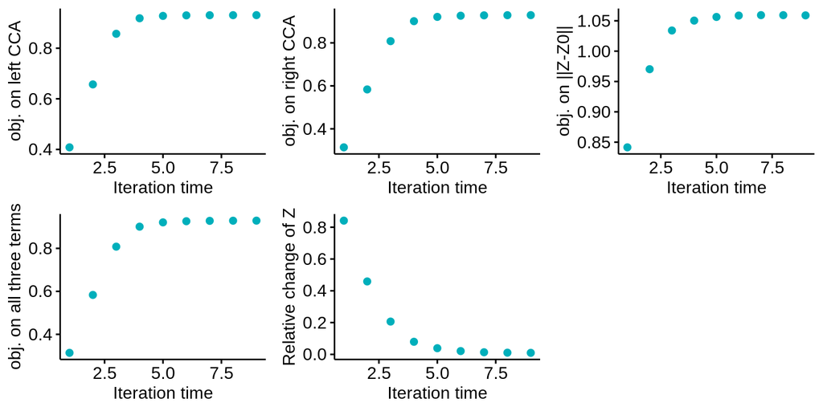

```r
p2 <- plotIteration(res)
p2
```

```r
tiff("iteration.cost.tiff", width=12, height =6, res =300, units = "in")
print(p2)
dev.off()
```

#### Stage 4: Project cells from two modalites in co-embedding spaces. `res$u` and `res$r` denote the coordinates of two modalites in co-embeddings.

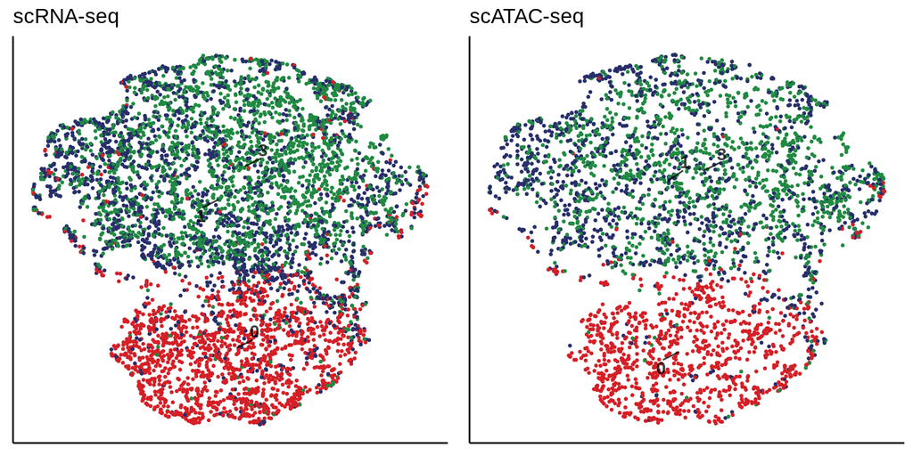

```r
library(umap)
dim(res$u)
dim(res$r)
umap_plt <- umap(rbind(res$u, res$r))
umap_plt  <- data.frame("UMAP1"=umap_plt$layout[,1],
                        "UMAP2"=umap_plt$layout[,2],
                        "celltype" = treatmentTime,
                        "data" = c(rep("scRNA-seq",ncol(X)),
                                   rep("scATAC-seq",ncol(Y))))

xlim <- c(min(umap_plt$UMAP1), max(umap_plt$UMAP1))
ylim <- c(min(umap_plt$UMAP2), max(umap_plt$UMAP2))

p11 <- UMAP_plot(meta = umap_plt[umap_plt$data=="scRNA-seq",],  alpha=1,
                color = "celltype", xlim = xlim, ylim = ylim, mylabel = paletteDiscrete(umap_plt$celltype) ) + ggtitle("scRNA-seq")
p12 <- UMAP_plot(meta = umap_plt[umap_plt$data=="scATAC-seq",],  alpha=1,
              color = "celltype", xlim = xlim, ylim = ylim,mylabel = paletteDiscrete(umap_plt$celltype) )  + ggtitle("scATAC-seq")

p3 <- ggarrange(p11,p12, ncol=2)
print(p3)
```

#### Stage 5: Impute gene expression profiles for cells from scATAC.

We can also show how bindSC improves the gene score matrix after iteration process using co-assayed cells as the validation. Given most of genes are not associated with DEX-treatment, the overall correlation is stilllower than 0.1.

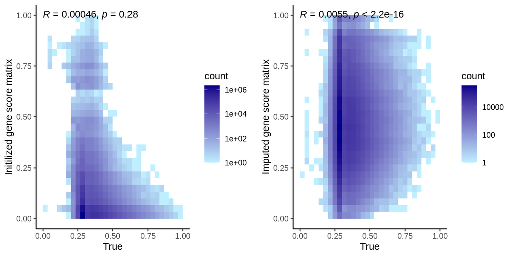

```r
Z_impu <- impuZ(X=X, bicca = res)
colnames(Z_impu) <- colnames(Z0)

coassay_cell <- intersect(colnames(X), colnames(Y))
p5 <- plot_geneScoreChange(X=X[,coassay_cell], Z0 = Z0[,coassay_cell], Z_impu = Z_impu[,coassay_cell])


tiff("matZ.improve.tiff", width=9, height =4, res =300, units = "in", compression = "lzw")
print(p5)
dev.off()
p5
```